# Homework 4: Data Visualization

#### Nicole Becker - On my honor, as a student, I have neither given nor received unauthorized aid on this academic work.

```python
import pandas as pd
import numpy as np
import matplotlib.pyplot as plt
import seaborn as sns

%matplotlib inline

print(sns.__version__)    #check seaborn version
```

```
0.9.0
```

```python
df = pd.read_csv("data/bank.csv")
df.head()
```

|  | CHK_ACCT | DURATION | HISTORY | NEW_CAR | USED_CAR | FURNITURE | RADIO/TV | EDUCATION | RETRAINING | AMOUNT | ... | AGE | OTHER_INSTALL | RENT | OWN_RES | NUM_CREDITS | JOB | NUM_DEPENDENTS | TELEPHONE | FOREIGN | RESPONSE |
| --- | --- | --- | --- | --- | --- | --- | --- | --- | --- | --- | --- | --- | --- | --- | --- | --- | --- | --- | --- | --- | --- |
| 0 | 0 | 6 | 4 | 0 | 0 | 0 | 1 | 0 | 0 | 1169 | ... | 67 | 0 | 0 | 1 | 2 | 2 | 1 | 1 | 0 | 1 |
| 1 | 1 | 48 | 2 | 0 | 0 | 0 | 1 | 0 | 0 | 5951 | ... | 22 | 0 | 0 | 1 | 1 | 2 | 1 | 0 | 0 | 0 |
| 2 | 3 | 12 | 4 | 0 | 0 | 0 | 0 | 1 | 0 | 2096 | ... | 49 | 0 | 0 | 1 | 1 | 1 | 2 | 0 | 0 | 1 |
| 3 | 0 | 42 | 2 | 0 | 0 | 1 | 0 | 0 | 0 | 7882 | ... | 45 | 0 | 0 | 0 | 1 | 2 | 2 | 0 | 0 | 1 |
| 4 | 0 | 24 | 3 | 1 | 0 | 0 | 0 | 0 | 0 | 4870 | ... | 53 | 0 | 0 | 0 | 2 | 2 | 2 | 0 | 0 | 0 |

5 rows × 31 columns

## 1. While columns or variables would significantly influence the Y value?

1) *DURATION* - the duration of the loan likely influences the applicant paying back. A longer loan probably increases the likelihood of a default.

2) *SAV_ACCT* - an average balance within this account indicates financial stability and an ability to pay back quickly with actual cash on hand.

3) *EMPLOYMENT* - duration of employment has indicates the applicant's stability in his or her job. It's preferred that an applicant has a stable job to be able to consistently contribute funds to pay back a loan.

## 2. What are some general findings from basic statistics?

```python
df.describe()
```

|  | CHK_ACCT | DURATION | HISTORY | NEW_CAR | USED_CAR | FURNITURE | RADIO/TV | EDUCATION | RETRAINING | AMOUNT | ... | AGE | OTHER_INSTALL | RENT | OWN_RES | NUM_CREDITS | JOB | NUM_DEPENDENTS | TELEPHONE | FOREIGN | RESPONSE |
| --- | --- | --- | --- | --- | --- | --- | --- | --- | --- | --- | --- | --- | --- | --- | --- | --- | --- | --- | --- | --- | --- |
| count | 1000.000000 | 1000.000000 | 1000.00000 | 1000.000000 | 1000.000000 | 1000.000000 | 1000.000000 | 1000.000000 | 1000.000000 | 1000.000000 | ... | 1000.000000 | 1000.000000 | 1000.000000 | 1000.000000 | 1000.000000 | 1000.000000 | 1000.000000 | 1000.000000 | 1000.000000 | 1000.000000 |
| mean | 1.577000 | 20.903000 | 2.54500 | 0.234000 | 0.103000 | 0.181000 | 0.280000 | 0.050000 | 0.097000 | 3271.258000 | ... | 35.546000 | 0.186000 | 0.179000 | 0.713000 | 1.407000 | 1.904000 | 1.155000 | 0.404000 | 0.037000 | 0.700000 |
| std | 1.257638 | 12.058814 | 1.08312 | 0.423584 | 0.304111 | 0.385211 | 0.449224 | 0.218054 | 0.296106 | 2822.736876 | ... | 11.375469 | 0.389301 | 0.383544 | 0.452588 | 0.577654 | 0.653614 | 0.362086 | 0.490943 | 0.188856 | 0.458487 |
| min | 0.000000 | 4.000000 | 0.00000 | 0.000000 | 0.000000 | 0.000000 | 0.000000 | 0.000000 | 0.000000 | 250.000000 | ... | 19.000000 | 0.000000 | 0.000000 | 0.000000 | 1.000000 | 0.000000 | 1.000000 | 0.000000 | 0.000000 | 0.000000 |
| 25% | 0.000000 | 12.000000 | 2.00000 | 0.000000 | 0.000000 | 0.000000 | 0.000000 | 0.000000 | 0.000000 | 1365.500000 | ... | 27.000000 | 0.000000 | 0.000000 | 0.000000 | 1.000000 | 2.000000 | 1.000000 | 0.000000 | 0.000000 | 0.000000 |
| 50% | 1.000000 | 18.000000 | 2.00000 | 0.000000 | 0.000000 | 0.000000 | 0.000000 | 0.000000 | 0.000000 | 2319.500000 | ... | 33.000000 | 0.000000 | 0.000000 | 1.000000 | 1.000000 | 2.000000 | 1.000000 | 0.000000 | 0.000000 | 1.000000 |
| 75% | 3.000000 | 24.000000 | 4.00000 | 0.000000 | 0.000000 | 0.000000 | 1.000000 | 0.000000 | 0.000000 | 3972.250000 | ... | 42.000000 | 0.000000 | 0.000000 | 1.000000 | 2.000000 | 2.000000 | 1.000000 | 1.000000 | 0.000000 | 1.000000 |
| max | 3.000000 | 72.000000 | 4.00000 | 1.000000 | 1.000000 | 1.000000 | 1.000000 | 1.000000 | 1.000000 | 18424.000000 | ... | 75.000000 | 1.000000 | 1.000000 | 1.000000 | 4.000000 | 3.000000 | 2.000000 | 1.000000 | 1.000000 | 1.000000 |

8 rows × 31 columns

*What is the average number of checking accounts?*

1.577 checking accounts (rounds to 2)

*What is the maximum loan duration?*

The maximum is 72 months.

*What is the minimum loan amount?*

The minimum loan amount is $250.

## 3. What portion of borrowers have paid back? What portion have defaulted on their loans?

```python
df.groupby('RESPONSE').size() / len(df)
```

```
RESPONSE
0    0.3
1    0.7
dtype: float64
```

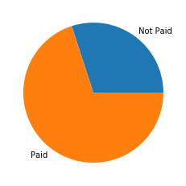

```python
plt.pie(df.groupby('RESPONSE').size(), labels = ["Not Paid", "Paid"]);
```

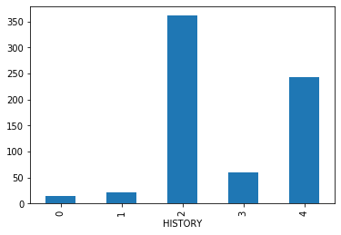

```python
df.groupby('HISTORY')['RESPONSE'].sum().plot.bar();
```

**Results**

## 4. Demonstrate your skills in groupby to extract business intelligence.

```python
df.groupby('RESPONSE').mean().T
```

| RESPONSE | 0 | 1 |
| --- | --- | --- |
| CHK_ACCT | 0.903333 | 1.865714 |
| DURATION | 24.860000 | 19.207143 |
| HISTORY | 2.166667 | 2.707143 |
| NEW_CAR | 0.296667 | 0.207143 |
| USED_CAR | 0.056667 | 0.122857 |
| FURNITURE | 0.193333 | 0.175714 |
| RADIO/TV | 0.206667 | 0.311429 |
| EDUCATION | 0.073333 | 0.040000 |
| RETRAINING | 0.113333 | 0.090000 |
| AMOUNT | 3938.126667 | 2985.457143 |
| SAV_ACCT | 0.673333 | 1.290000 |
| EMPLOYMENT | 2.170000 | 2.475714 |
| INSTALL_RATE | 3.096667 | 2.920000 |
| MALE_DIV | 0.066667 | 0.042857 |
| MALE_SINGLE | 0.486667 | 0.574286 |
| MALE_MAR_or_WID | 0.083333 | 0.095714 |
| CO-APPLICANT | 0.060000 | 0.032857 |
| GUARANTOR | 0.033333 | 0.060000 |
| PRESENT_RESIDENT | 2.850000 | 2.842857 |
| REAL_ESTATE | 0.200000 | 0.317143 |
| PROP_UNKN_NONE | 0.223333 | 0.124286 |
| AGE | 33.963333 | 36.224286 |
| OTHER_INSTALL | 0.253333 | 0.157143 |
| RENT | 0.233333 | 0.155714 |
| OWN_RES | 0.620000 | 0.752857 |
| NUM_CREDITS | 1.366667 | 1.424286 |
| JOB | 1.936667 | 1.890000 |
| NUM_DEPENDENTS | 1.153333 | 1.155714 |
| TELEPHONE | 0.376667 | 0.415714 |
| FOREIGN | 0.013333 | 0.047143 |

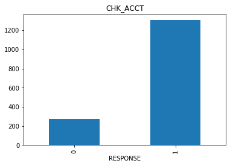

```python
df.groupby('RESPONSE')['CHK_ACCT'].sum().plot.bar();
plt.title('CHK_ACCT')
```

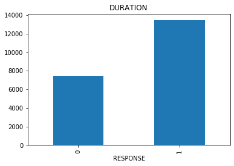

```python
df.groupby('RESPONSE')['DURATION'].sum().plot.bar();
plt.title('DURATION');
```

There are numerous variables that seem to impact who's likely to pay back their loan. The following variables/relationships seem to have an influence on one's ability to pay back the loan.

- CHK_ACCT - Higher checking account status, more likely to pay back
- DURATION - Shorter duration, more likely to pay back
- HISTORY - Higher status, more likely to pay back
- AMOUNT - Lower loan account, more likely to pay back
- EMPLOYMENT - Longer at present employer, more likely to pay back
- AGE - Older, more likely to pay back

## 5. Demonstrate your skills in pivot tables to extract business intelligence.

```python
df.pivot_table(index='EMPLOYMENT', columns='HISTORY', values='RESPONSE', aggfunc='sum', fill_value=0)
```

| HISTORY EMPLOYMENT | 0 | 1 | 2 | 3 | 4 |
| --- | --- | --- | --- | --- | --- |
| 0 | 0 | 2 | 19 | 3 | 15 |
| 1 | 3 | 3 | 69 | 4 | 23 |
| 2 | 8 | 9 | 124 | 27 | 67 |
| 3 | 1 | 4 | 67 | 14 | 49 |
| 4 | 3 | 3 | 82 | 12 | 89 |

- The combination of 'EMPLOYMENT' and 'HISTORY' with the highest number to pay back at a value of (2,2) for each criteria.
- This indicates a person who has paid all existing credits duly until now and has worked at his or her present job between 1 and 4 years is more likely to pay.

```python
pd.pivot_table(df, index='RESPONSE', columns='EMPLOYMENT', values ='AMOUNT', aggfunc='max')
```

| EMPLOYMENT RESPONSE | 0 | 1 | 2 | 3 | 4 |
| --- | --- | --- | --- | --- | --- |
| 0 | 14555 | 15945 | 18424 | 14027 | 14896 |
| 1 | 15857 | 10722 | 12204 | 15653 | 13756 |

- The person with the highest loan ($18,424) defaulted, which is what you would expect
- Higher loan amounts are more difficult to pay back

```python
pd.pivot_table(df, index='RESPONSE', columns='CHK_ACCT', values ='DURATION', aggfunc='mean')
```

| CHK_ACCT RESPONSE | 0 | 1 | 2 | 3 |
| --- | --- | --- | --- | --- |
| 0 | 24.629630 | 26.733333 | 18.071429 | 23.326087 |
| 1 | 18.143885 | 20.085366 | 17.142857 | 19.508621 |

- Consistently, those who had paid back have had a loan for a shorter duration, with the lowest average when there's also a checking account status of 2

```python
pd.pivot_table(df, index='RESPONSE', columns='EMPLOYMENT', values ='CHK_ACCT', aggfunc='count')
```

| EMPLOYMENT RESPONSE | 0 | 1 | 2 | 3 | 4 |
| --- | --- | --- | --- | --- | --- |
| 0 | 23 | 70 | 104 | 39 | 64 |
| 1 | 39 | 102 | 235 | 135 | 189 |

- Most people fall within the '2' level of "EMPLOYMENT"
- The people within that range have the highest number of people who paid back, but it would also be good to look at this in terms of percentages

## 6. What is the relationship between RESPONSE and the three variables chosen in question 1?

### DURATION

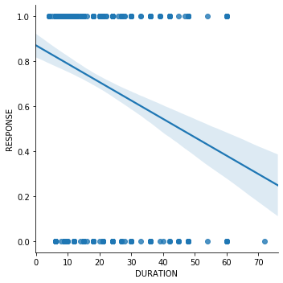

```python
sns.lmplot('DURATION', 'RESPONSE', data=df, fit_reg=True);
```

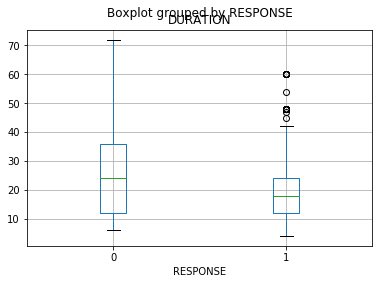

```python
df.boxplot(column='DURATION', by='RESPONSE');
```

**Results:** Duration and response are negatively correlated, so a longer duration loan is more likely to default. The boxplot reiterates the same thing as the default loans have a higher mean and wider range for duration then the successful loans.

### SAV_ACCT

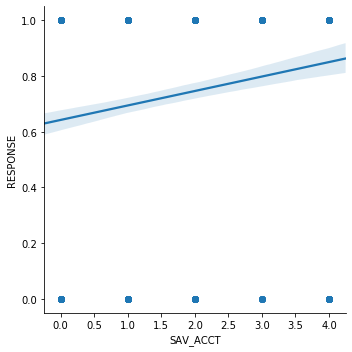

```python
sns.lmplot('SAV_ACCT', 'RESPONSE', data=df, fit_reg=True);
```

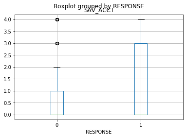

```python
df.boxplot(column='SAV_ACCT', by='RESPONSE');
```

**Results:** While the correlation isn't super strong,there's a positive relationship between RESPONSE and SAV_ACCT. Therefore, if there's a higher amount in one's savings account, he or she is more likely to pay the loan.

### EMPLOYMENT

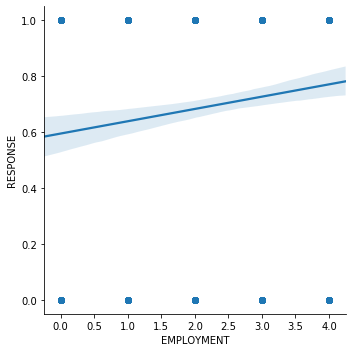

```python
sns.lmplot('EMPLOYMENT', 'RESPONSE', data=df, fit_reg=True);
```

[figure not shown]

```python
df.boxplot(column='SAV_ACCT', by='RESPONSE');
```

**Results:** While the correlation isn't super strong,there's a positive relationship between RESPONSE and EMPLOYMENT. Therefore, if there's a higher status for one's employment, he or she is more likely to pay the loan. The employment status indicates how long the person has been at his or her present employer. From past analysis, the most common spot for that is at status '2' or between 1-4 years.

## 7. Visualize the relationship between DURATION and RESPONSE.

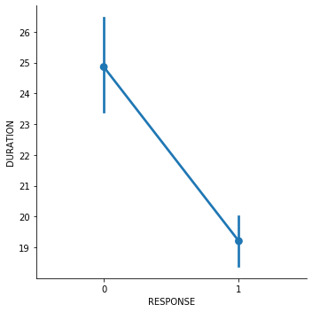

```python
sns.catplot("RESPONSE", "DURATION", data=df, kind="point")
```

It's obvious those applicants that default have much higher loan durations.

## 8. What variables appear to be highly influential in determining Y value (RESPONSE)?

**FactorPlot**

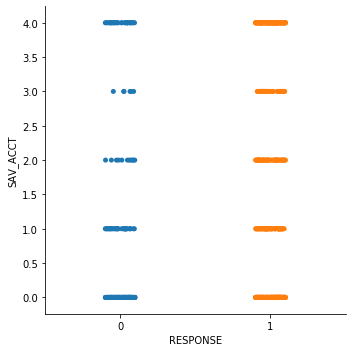

```python
sns.catplot("RESPONSE", "SAV_ACCT", data=df)
```

**lmplot/Regression**

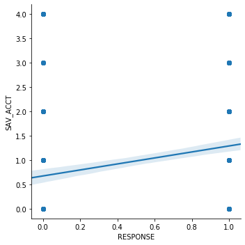

```python
sns.lmplot('RESPONSE', 'SAV_ACCT', data=df, fit_reg=True);
```

**Joinplot**

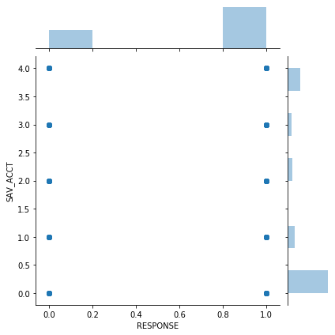

```python
sns.jointplot("RESPONSE", "SAV_ACCT", df);
```

**Pairplot:**

My computer couldn't run the results - wouldn't load.

**Facegrid**

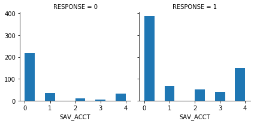

```python
g = sns.FacetGrid(df, col="RESPONSE")
g.map(plt.hist, "SAV_ACCT")
```

**Density plot**

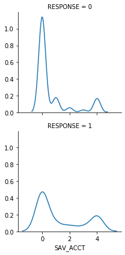

```python
g = sns.FacetGrid(df, row="RESPONSE")
g.map(sns.kdeplot, "SAV_ACCT")
```

**Violin plot**

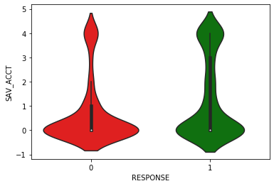

```python
sns.violinplot("RESPONSE", "SAV_ACCT", data=df,
               palette=["red", "green"])
```

## 9. Find relationship between HISTORY and RESPONSE

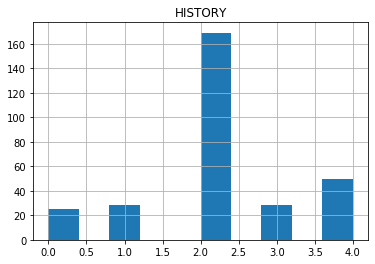

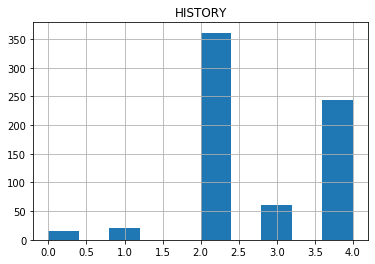

```python
df.groupby('RESPONSE').hist('HISTORY');
```

```python
df1 =df[(df['RESPONSE'] == 1)]
g = df.groupby('HISTORY').size()
h = df1.groupby('HISTORY').size()
prob = h/g
prob
```

```
HISTORY
0    0.375000
1    0.428571
2    0.681132
3    0.681818
4    0.829352
dtype: float64
```

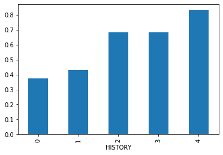

```python
prob.plot(kind='bar')
```

**Results**

A history of '2' is most common, but actually a history of '4' is more likely to pay back. However, a history of '2' or '3' are next most likely to pay back, and they have a higher raw number.

## 10. Formulate own question

### What is the relationship between age and response?

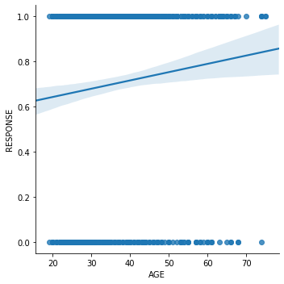

```python
sns.lmplot('AGE', 'RESPONSE', data=df, fit_reg=True);
```

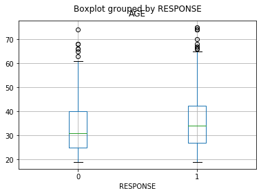

```python
df.boxplot(column='AGE', by='RESPONSE');
```

**Results:** Those who pay off their loan typically have a slightly higher age. However, most of those applying for a loan are around age 30 in the first place.

## 11. Formulate own question.

### Which relationship status has a higher correlation with response?

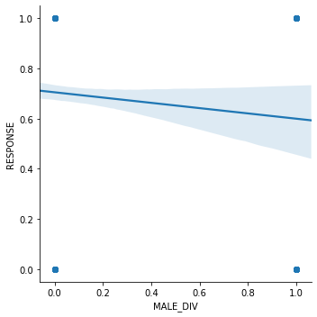

```python
sns.lmplot('MALE_DIV', 'RESPONSE', data=df, fit_reg=True);
```

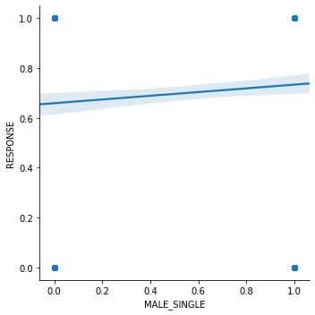

```python
sns.lmplot('MALE_SINGLE', 'RESPONSE', data=df, fit_reg=True);
```

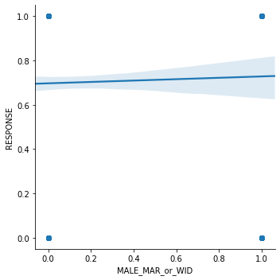

```python
sns.lmplot('MALE_MAR_or_WID', 'RESPONSE', data=df, fit_reg=True);
```

**Results**

A divorced man is less likely to pay the loan, and a single man is more likely to pay the loan. These factors are likley inversely related. Meanwhile, a married or widowed man seems to have little correlation to response.

## 12. What are the characteristics of the people who have paid back?

### Data Analysis Summary

After complete analysis of the current dataset, we can start to draw conclusions regarding the type of people who are most likely to pay off their loans. This is crucial to the operation of this bank, as with such information, we can make better decisions and make more money through lending money. The following information is profiles of people likely to pay their loans and those who are likely to default.

*Likely to Pay Back*

1. Checking Account
   - Those with a higher checking account status are more likely to pay back
   - Interesting observation: There were many people who had paid back with an 'unknown' checking account status
   - Particularly, those with a status of '2' are most likely to pay back
1. Amount
   - A lower loan amount indicates the person is more likely to pay back
   - The average loan amount of those who pay back is $1,000 lower than the average of those who don't
2. Duration
   - A shorter loan duration indicates the person is more likely to pay back
   - The average duration of those who pay back is 5 months lower than the average of those who don't
   - Duration seems to have one of the largest impacts on one's ability to pay off
   - I would recommend highly considering duration when evaluating applicants

*Likely to Not Pay Back*

1. History
   - A lower history status indicates the person is less likely to pay back
   - A majority of applicants have history of '2' status
   - Those who are most probably to pay back have a '4' status and second to that is a '2' and '3' status
2. Age
   - A lower loan amount indicates the person is more likely to pay back
   - The average age of those who paid back is higher than the average age of those who don't
   - Most applicants seems to be in their 30's
3. Employment
   - Most fall within the '2' status range, which mean they worked at their current employer for between 1 and 4 years

### Overall

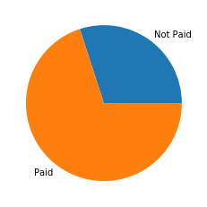

```python
plt.pie(df.groupby('RESPONSE').size(), labels = ["Not Paid", "Paid"]);
```

Currently, more people have paid than not paid, which is good. The bank should continue to seek out people with the previously mentioned criteria, and should be weary of those who have the opposite characteristics.With this, they will be able to increase profits.